# Data Envelopment Analysis (DEA)

Muthia Salsabila

This Notebook show how to estimate and measure efficiency using Data Envelopment Analysis (DEA) method and Benchmarking package in R.

What is Efficiency?  
Efficiency is when a firm can minimize its input to produce a particular output. There are three types of efficiency, which are technical efficiency, allocative efficiency, and economic efficiency. Technical efficiency is a firm ability to reach optimal output using a particular input. Allocative efficiency is a firm ability to use optimal input to reach a certain level of output. Economic efficiency is a combination between technical efficiency and allocative efficiency.

Efficiency can be measure with DEA and SFA. We will be using DEA method for measuring the efficiency.

What is Data Envelopment Analysis?  
Data Envelopment Analysis (DEA) is a non-parametric linear programming approach for measuring efficiency that can measure multiple-input and multiple-output. DEA introduced by Charnes, Coopers, and Rhodes in 1978.

There are two assumptions in DEA, which are Constant Return to Scale (CRS) and Variable Return to Scale (VRS).

- CRS assume a firm operate at optimum scale and the ratio of increasing input is equal to output, which mean if there is an addition to input x times then the output will increase x times too. CRS model often define as CCR model because it introduced by Charnes, Cooper, and Rhodes.
- VRS (or known as BCC model, developed by Banker, Charnes, and Cooper) assume a firm not or not yet operate at optimum scale and the ratio between input and ouput is not equal. When there is an addition to input x times, the output can increase more than x or lower than x.

There’s also two approach in DEA:

- Input oriented = minimizing input to reach a certain level of output
- output oriented = maximizing output using a particular combination of input

Step of Project  
1. Loading Packages  
2. Import Data  
3. Select Input and Output  
4. Estimate Efficiencies  
5. Measure Slack  
6. Plot Frontier

Loading Packages  
The first step is to load the Benchmarking package using library function. This package contains methods to estimate and measure efficiency using DEA and SFA.

```r
library(Benchmarking)
```

Import data  
This package also contains a few datasets that can be used for practice. The datasets I use called *milkProd*, which is a data from Danish milk producers. I also use dplyr package to see a glimpse of data rows, column, and type.

```r
#import data
data("milkProd")
milkProd
```

```
##     farmNo    milk energy    vet cows
## 1        1  862533 117894  21186  121
## 2        2  605764  72049  43910   80
## 3        3  865658 158466  54583   95
## 4        4  662331  66783  45469   87
## 5        5 1003444 101714  81625  125
## 6        6  923512 252408  96807  135
## 7        7  563685 131025  51901   87
## 8        8 1247312 154591  38164  171
## 9        9  992729 187575  82810  165
## 10      10 1209692 251479  72818  154
## 11      11  575313  71678  43034   79
## 12      12  494145 123044  13743   99
## 13      13  962390 188050  51897  107
## 14      14  889904 160004  50729  111
```

[output cut: 94 more lines]

```r
dplyr::glimpse(milkProd)
```

```
## Rows: 108
## Columns: 5
## $ farmNo <int> 1, 2, 3, 4, 5, 6, 7, 8, 9, 10, 11, 12, 13, 14, 15, 16, 17, 18, ~
## $ milk   <int> 862533, 605764, 865658, 662331, 1003444, 923512, 563685, 124731~
## $ energy <int> 117894, 72049, 158466, 66783, 101714, 252408, 131025, 154591, 1~
## $ vet    <int> 21186, 43910, 54583, 45469, 81625, 96807, 51901, 38164, 82810, ~
## $ cows   <int> 121, 80, 95, 87, 125, 135, 87, 171, 165, 154, 79, 99, 107, 111,~
```

As we can see, the data has 108 rows and 5 columns with all variables data type are integer. The variable name meaning are as follows:

- **farmNO** = farm number
- **milk** = Output of milk, kg
- **energy** = Energy Expenses
- **vet** = Veterinary expenses
- **cows** = Number of Cows

Select Input and Output  
To estimate the efficiency, we must select which variables from the data are input and which are the output. DEA can select multiple output and multiple input, but in this case we use only one output and multiple input.

```r
# input output selection
x <- with(milkProd, cbind(energy, vet, cows))
y <- with(milkProd, cbind(milk))
```

X define the input variables which are energy expenses, veterinary expenses, and number of cows. While y define the output variable which is milk in kilogram.

Calculate Efficiency  
After we select the input and output, we can calculate the efficiency using dea function as follows:

```r
#calculating efficiency
#VRS (bcc)
bcc <- dea(x, y, RTS = "vrs", ORIENTATION = "in")
eff(bcc)
```

```
##   [1] 1.0000000 0.8844248 0.9964530 0.9073615 0.9247900 0.7439829 0.7417086
##   [8] 0.9983316 0.6508284 0.8985446 0.8529547 0.6730465 0.9749370 0.8746228
##  [15] 0.9612959 0.8798740 0.7740659 1.0000000 0.7974214 0.8380647 0.9214881
##  [22] 0.8466635 0.6816404 0.9411051 0.7985195 0.8338680 0.8867200 1.0000000
##  [29] 1.0000000 0.8354960 1.0000000 0.9138441 1.0000000 1.0000000 0.6641207
##  [36] 0.7993055 0.8317462 0.7967560 0.7751629 1.0000000 1.0000000 0.7965694
##  [43] 0.8541166 0.8460606 0.8519376 0.5936892 0.9092675 0.8262730 0.8521087
##  [50] 0.9280546 0.8759278 1.0000000 1.0000000 0.8027888 0.6284807 0.7811798
##  [57] 0.7657584 1.0000000 1.0000000 0.8897330 0.9124867 0.8332759 0.9199263
##  [64] 0.9044265 0.6201782 0.9933319 0.7844554 0.8419748 0.8932946 0.8443652
##  [71] 0.9127449 0.9099331 0.9276124 0.8158349 0.7200275 0.8220379 0.9180417
##  [78] 0.7517989 0.8924859 0.7415167 0.9922742 0.9502334 1.0000000 0.9201801
##  [85] 0.7566123 0.7131812 0.5383167 0.9167356 0.8887702 0.9637106 0.9540187
##  [92] 0.6218999 0.9855879 0.9220796 0.8290510 0.8956272 0.8945004 0.6462622
##  [99] 0.9528539 0.9757119 0.9167640 1.0000000 0.8601009 0.9464849 1.0000000
## [106] 0.8411605 0.9175846 0.8914390
```

We use BCC model and input-oriented.

```r
summary(bcc)
```

```
## Summary of efficiencies
## VRS technology and input orientated efficiency
## Number of firms with efficiency==1 are 16 out of 108
## Mean efficiency: 0.868
## ---
##   Eff range       #    %
##   0.5<= E <0.6    2  1.9
##   0.6<= E <0.7    8  7.4
##   0.7<= E <0.8   17 15.7
##   0.8<= E <0.9   33 30.6
##   0.9<= E <1     32 29.6
##         E ==1    16 14.8
##    Min. 1st Qu.  Median    Mean 3rd Qu.    Max.
##  0.5383  0.8019  0.8906  0.8681  0.9509  1.0000
```

From the summary we can see there are 16 DMUs categorized as efficient, and the mean efficiency is 0.868.

We also can see how much DMUs become a peers for other DMU. As we see below, L34 or DMU number 34 become peers for 80 other DMUs.

```r
get.number.peers(bcc)
```

```
##      peer count
## L1      1     2
## L18    18     2
## L28    28    12
## L29    29    47
## L31    31     7
## L33    33     5
## L34    34    80
## L40    40     3
## L41    41     1
## L52    52     3
## L53    53    21
## L58    58     2
## L59    59     6
## L83    83    38
## L102  102     1
## L105  105    33
```

Using get.which.peers function, we can see DMUs group by its peer.

```r
get.which.peers(bcc)
```

```
## $L1
## [1]  1 90
##
## $L18
## [1] 18 44
##
## $L28
##  [1]  8 10 15 21 28 32 43 56 63 88 95 97
##
## $L29
##  [1]   2   4   5   9  11  16  19  20  24  25  26  29  30  37  39  42  46  47  49
## [20]  51  55  57  60  62  64  65  66  67  69  71  74  76  77  78  80  81  85  86
## [39]  88  91  92  93  97  98  99 100 101
##
## $L31
## [1]  8 12 15 23 31 73 90
##
## $L33
## [1]  8 33 49 86 88
##
## $L34
##  [1]   2   3   4   5   6   9  10  11  13  14  15  16  17  19  20  21  22  24  25
## [20]  26  30  32  34  37  38  39  42  43  44  45  46  47  49  50  51  54  55  56
## [39]  57  60  61  62  63  64  66  67  68  69  70  71  73  74  75  76  77  78  79
## [58]  80  81  82  84  86  87  88  90  92  93  94  95  96  97  98  99 100 101 103
## [77] 104 106 107 108
##
## $L40
## [1] 27 40 91
##
## $L41
## [1] 41
##
## $L52
## [1] 12 23 52
##
## $L53
##  [1]   7  17  20  26  35  36  37  46  48  53  65  66  71  72  75  77  89  98 101
## [20] 103 104
##
## $L58
## [1] 58 85
##
## $L59
## [1] 12 49 59 80 86 90
##
## $L83
##  [1]   3   6   7  12  13  14  17  22  23  35  36  38  45  48  50  54  61  65  68
## [20]  70  72  73  75  79  80  82  83  84  85  87  89  94  96 103 104 106 107 108
##
## $L102
## [1] 102
##
## $L105
##  [1]   2   4   5   9  11  16  19  24  25  27  30  39  42  44  47  51  55  57  60
## [20]  62  64  67  69  74  76  78  81  92  93  97  99 100 105
```

While below is a list of DMU with their reference peer. DMU number 2 follow DMU 29, DMU 34, and DMU 105 as an example so DMU number 2 can be efficient.

```r
print(peers(bcc,NAMES=TRUE),quote=FALSE)
```

```
##        peer1 peer2 peer3 peer4
##   [1,] 1     <NA>  <NA>  <NA>
##   [2,] 29    34    105   <NA>
##   [3,] 34    83    <NA>  <NA>
##   [4,] 29    34    105   <NA>
##   [5,] 29    34    105   <NA>
##   [6,] 34    83    <NA>  <NA>
##   [7,] 53    83    <NA>  <NA>
##   [8,] 28    31    33    <NA>
##   [9,] 29    34    105   <NA>
##  [10,] 28    34    <NA>  <NA>
##  [11,] 29    34    105   <NA>
##  [12,] 31    52    59    83
##  [13,] 34    83    <NA>  <NA>
##  [14,] 34    83    <NA>  <NA>
```

[output cut: 94 more lines]

Measure Slack  
By measuring slack, we can know which DMU need to reduce its input to achieve efficiency. If the result show “FALSE”, it means the DMU does not need to adjust the input. But if the result show “TRUE”, it means the DMU need to adjust its input by decreasing it to achieve efficiency.

```r
s1 <- slack(x, y, bcc)
t <- data.frame(milkProd$farmNo, eff(bcc), s1$slack, s1$sx)
t
```

```
##     milkProd.farmNo  eff.bcc. s1.slack         sx1        sx2        sx3
## 1                 1 1.0000000    FALSE     0.00000     0.0000  0.0000000
## 2                 2 0.8844248     TRUE     0.00000 14137.8443  0.0000000
## 3                 3 0.9964530     TRUE 45551.15902 29773.6018  0.0000000
## 4                 4 0.9073615     TRUE     0.00000  6751.9245  0.0000000
## 5                 5 0.9247900     TRUE     0.00000 22465.5862  0.0000000
## 6                 6 0.7439829     TRUE 70007.39634 45261.9805  0.0000000
## 7                 7 0.7417086     TRUE 13756.80032 24639.1559  0.0000000
## 8                 8 0.9983316     TRUE     0.00000     0.0000  0.4754134
## 9                 9 0.6508284     TRUE     0.00000 24028.4125  0.0000000
## 10               10 0.8985446     TRUE 95340.42532 21477.6225  0.0000000
## 11               11 0.8529547     TRUE     0.00000 13975.2683  0.0000000
## 12               12 0.6730465    FALSE     0.00000     0.0000  0.0000000
## 13               13 0.9749370     TRUE 61910.08004 22394.1109  0.0000000
## 14               14 0.8746228     TRUE 25315.95646 18854.0104  0.0000000
```

[output cut: 94 more lines]

As we can see the DMU that already achieve efficiency does not need to adjust its input.

Let’s take a look at other DMU that still not efficient. DMU 2 need to reduce veterinary expenses by 14137.8443 to achieve efficiency. Meanwhile, DMU 3 need to reduce energy expense by 45551.15902 and veterinary expense by 29773.6018 to achieve efficiency. If we take a deep look at the list, we can see there’s not much result that show we should reduce cow input. It is because reducing the number of cow not making sense. But, we can reduce the expenses of energy and veterinary to minimize the input and achieve optimal output.

Plot Frontier  
We can visualize the result by plotting the DMU in basic plot of frontier. The red line is frontier for Variable return to scale, and the green dash line is constant return to scale.

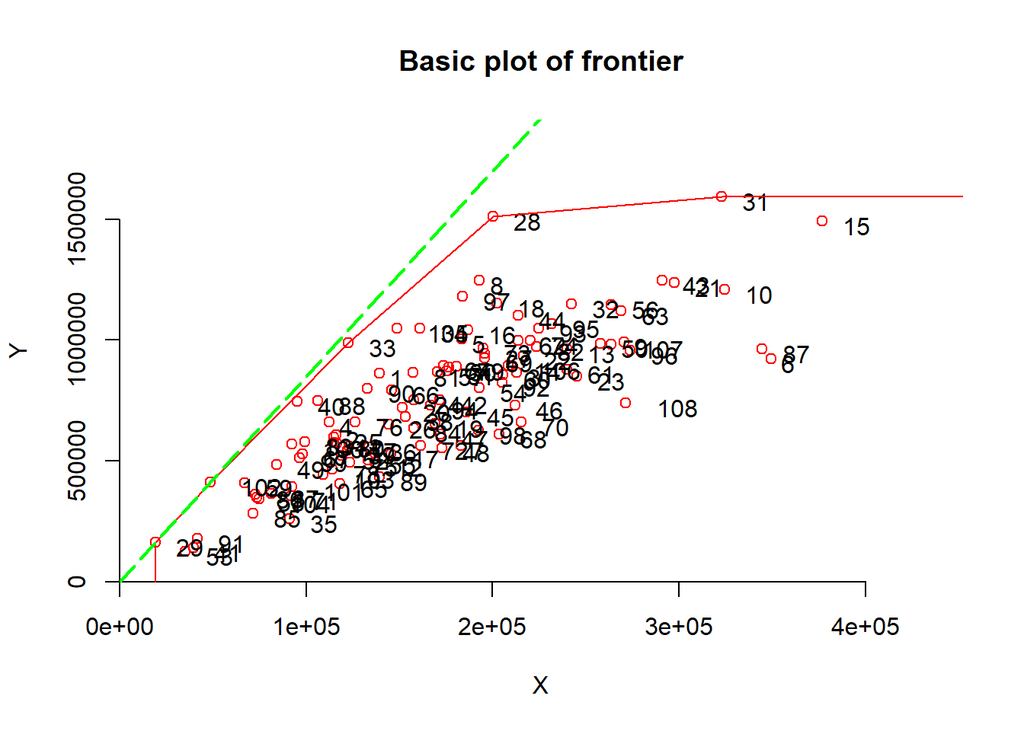

```r
dea.plot(x,y, txt=1:dim(x)[1],main="Basic plot of frontier", col = "red")
dea.plot(x,y,RTS="crs",add=TRUE,lty="longdash", lwd="2", col="green")
```

Conclusion  
The number of Farm that produce milk efficiently are still lower than the inefficient one. There are only 16 farms that produce milk efficiently, while other 92 farms still produce milk inefficiently. To achieve efficiency, farm can reduce its input which are energy expenses and veterinary expenses but there is no need to reduce the number of cows because it does not make sense to reduce the cows unless they die.